# Read in steinbock data

2022-08-12

# Read in the data

This section describes how to read in single-cell data and images into `R` **after** image processing and segmentation (see Section @ref(processing)).

We use the imcRtools package to read in single-cell data extracted using the `steinbock` framework or the IMC Segmentation Pipeline. Both image processing approaches also generate multi-channel images and segmentation masks that can be read into `R` using the cytomapper package.

```r
library(imcRtools)
library(cytomapper)
library(BiocParallel)
```

## Read in single-cell information

For single-cell data analysis in `R` the [SingleCellExperiment](https://bioconductor.org/packages/release/bioc/html/SingleCellExperiment.html) [@Amezquita2019] data container is commonly used within the Bioconductor framework. It allows standardized access to (i) expression data, (ii) cellular metadata (e.g. cell type), (iii) feature metadata (e.g. marker name) and (iv) experiment-wide metadata. For an in-depth introduction to the `SingleCellExperiment` container, please refer to the [SingleCellExperiment class](https://bioconductor.org/books/3.14/OSCA.intro/the-singlecellexperiment-class.html).

The [SpatialExperiment](https://bioconductor.org/packages/release/bioc/html/SingleCellExperiment.html) class [@Righelli2021] is an extension of the `SingleCellExperiment` class. It was developed to store spatial data in addition to single-cell data and an extended introduction is accessible [here](https://bioconductor.org/packages/release/bioc/vignettes/SpatialExperiment/inst/doc/SpatialExperiment.html).

To read in single-cell data generated by the `steinbock` framework or the IMC Segmentation Pipeline, the `imcRtools` package provides the `read_steinbock` and `read_cpout` function, respectively. By default, the data is read into a `SpatialExperiment` object; however, data can be read in as a `SingleCellExperiment` object by setting `return_as = "sce"`. All functions presented in this book are applicable to both data containers.

### steinbock generated data

The steinbock framework was used to process and segment IMC raw data available.

The `read_steinbock` function provided by `imcRtools` can now be used to read in `steinbock` generated data. For more information, please refer to `?read_steinbock`.

```r
path <- "/mnt/Multimodal_Imaging_Daria/_Data_Analysis/_tmp_daria/Image_analysis/20220723_Steinbock_Mesmer_IFbased"

spe <- read_steinbock(path=path,
    extract_cellid_from = "Object",
    extract_coords_from = c("centroid-1", "centroid-0"),
    image_file = NULL,
    panel_file = file.path(path, 'NB_Panel.csv'),
    extract_names_from = "name",
    BPPARAM = MulticoreParam(workers=12))
spe
```

```
## class: SpatialExperiment
## dim: 47 948370
## metadata(0):
## assays(1): counts
## rownames(47): Myeloperoxidase MPO CD44 ... GD2-IF CD56-IF
## rowData names(4): name channel keep deepcell
## colnames: NULL
## colData names(6): sample_id ObjectNumber ... minor_axis_length
##   eccentricity
## reducedDimNames(0):
## mainExpName: NULL
## altExpNames(0):
## spatialCoords names(2) : Pos_X Pos_Y
## imgData names(1): sample_id
```

By default, single-cell data is read in as `SpatialExperiment` object. The summarized pixel intensities per channel and cell (here mean intensity) are stored in the `counts` slot. Columns represent cells and rows represent channels.

```r
rowData(spe)
```

```
## DataFrame with 47 rows and 4 columns
##                                    name     channel      keep  deepcell
##                             <character> <character> <numeric> <numeric>
## Myeloperoxidase MPO Myeloperoxidase MPO         Y89         1        NA
## CD44                               CD44       In115         1         2
## 131Xe                             131Xe       Xe131         1        NA
## 134Xe                             134Xe       Xe134         1        NA
## 136Ba                             136Ba       Ba136         1        NA
## ...                                 ...         ...       ...       ...
## Vimentin                       Vimentin       Pt196         1        NA
## CD15                               CD15       Bi209         1         2
## DAPI                               DAPI        DAPI         1         1
## GD2-IF                           GD2-IF      GD2_IF         1        NA
## CD56-IF                         CD56-IF     CD56_IF         1        NA
```

```r
counts(spe)[1:47,1:2]
```

```
##                                           [,1]        [,2]
## Myeloperoxidase MPO                 0.02439024  0.10344828
## CD44                                0.00000000  0.05659674
## 131Xe                              44.31288682 40.15019187
## 134Xe                              19.01961857 20.27109054
## 136Ba                              15.77821973 14.68538840
## Fibronectin                         0.03636670  0.03448276
## CD11b                               0.00000000  0.09741622
## HLA-DR                              0.04935127  0.00000000
## PRPH                                0.07064743  0.03448276
## CXCR2- IL-8 RB                      0.02439024  0.00000000
## Histone H3K9Ac                      0.00000000  0.00000000
## HLA-ABC                             0.00000000  0.03448276
## CD20                                0.00000000  0.00000000
## LUM                                 0.00000000  0.00000000
## CD11c                               0.00000000  0.00000000
## CD24                                0.04878049  0.03448276
## CD3                                 0.00000000  0.00000000
## CD45                                0.00000000  0.06688855
## CD8a                                0.00000000  0.00000000
## GD2                                 0.31914817  0.10500815
## CD34                                0.00000000  0.00000000
## CD10                                0.12734899  0.08554732
## CXCR4                               0.00000000  0.00000000
## CD274 (B7-H1- PD-L1)                0.02439024  0.03904356
## S100B                               0.02439024  0.00000000
## SOX10                               0.00000000  0.00000000
## FOXP3                               0.00000000  0.00000000
## Chromogranin A                      0.04878049  0.00000000
## CD279 (PD-1)                        0.00000000  0.00000000
## PNMT                                0.00000000  0.04074508
## H4K12Ac                             0.00000000  0.00000000
## GATA3                               0.00000000  0.00000000
## Ki-67                               0.00000000  0.03648174
## CD56                                0.00000000  0.00000000
## CD4                                 0.00000000  0.00000000
## Indoleamine 2- 3-dioxygenase (IDO)  0.00000000  0.00000000
## Granzyme B                          0.00000000  0.00000000
## ELAVL4                              0.05947418  0.06344368
## CD14                                0.00000000  0.00000000
## cleaved PARP                        0.00000000  0.00000000
## Iridium191                          0.03711853  0.00000000
## Iridium193                          0.00000000  0.00000000
## Vimentin                            0.00000000  0.13396889
## CD15                                0.17350867  0.38639022
## DAPI                               72.27022199 82.02363955
## GD2-IF                             61.16163300 16.41978718
## CD56-IF                            39.89831841 42.09577047
```

```r
head(colData(spe))
```

```
## DataFrame with 6 rows and 6 columns
##                sample_id ObjectNumber      area major_axis_length
##              <character>    <numeric> <numeric>         <numeric>
## 1 20211222_03-0313_BM_..            1        41          10.67939
## 2 20211222_03-0313_BM_..            2        29           7.33853
## 3 20211222_03-0313_BM_..            3        37           9.52947
## 4 20211222_03-0313_BM_..            4        49           8.49524
## 5 20211222_03-0313_BM_..            5        76          11.63923
## 6 20211222_03-0313_BM_..            6        55           8.86617
##   minor_axis_length eccentricity
##           <numeric>    <numeric>
## 1           4.98583     0.884329
## 2           5.02133     0.729254
## 3           5.03835     0.848801
## 4           7.31063     0.509356
## 5           8.45859     0.686923
## 6           7.89015     0.456122
```

```r
typeof(colData(spe))
```

```
## [1] "S4"
```

```r
class(spe)
```

```
## [1] "SpatialExperiment"
## attr(,"package")
## [1] "SpatialExperiment"
```

```r
class(colData(spe))
```

```
## [1] "DFrame"
## attr(,"package")
## [1] "S4Vectors"
```

```r
nrow(colData(spe))
```

```
## [1] 948370
```

```r
colData(spe)[1:5, 2:ncol(colData(spe))]
```

```
## DataFrame with 5 rows and 5 columns
##   ObjectNumber      area major_axis_length minor_axis_length eccentricity
##      <numeric> <numeric>         <numeric>         <numeric>    <numeric>
## 1            1        41          10.67939           4.98583     0.884329
## 2            2        29           7.33853           5.02133     0.729254
## 3            3        37           9.52947           5.03835     0.848801
## 4            4        49           8.49524           7.31063     0.509356
## 5            5        76          11.63923           8.45859     0.686923
```

The main difference between the `SpatialExperiment` and the `SingleCellExperiment` data container in the current setting is the way spatial locations of all cells are stored. For the `SingleCellExperiment` container, the locations are stored in the `colData` slot while the `SpatialExperiment` container stores them in the `spatialCoords` slot:

```r
head(spatialCoords(spe))
```

```
##      Pos_X    Pos_Y
## 1 153.4634 1.609756
## 2 296.0000 1.758621
## 3 624.0000 1.621622
## 4 684.4286 2.836735
## 5 224.8816 3.144737
## 6 695.6727 3.327273
```

Finally, metadata regarding the channels are stored in the `rowData` slot. This information is extracted from the `panel.csv` file. Channels are ordered by isotope mass and therefore match the channel order of the multi-channel images (see Section @ref(read-images)).

```r
head(rowData(spe))
```

```
## DataFrame with 6 rows and 4 columns
##                                    name     channel      keep  deepcell
##                             <character> <character> <numeric> <numeric>
## Myeloperoxidase MPO Myeloperoxidase MPO         Y89         1        NA
## CD44                               CD44       In115         1         2
## 131Xe                             131Xe       Xe131         1        NA
## 134Xe                             134Xe       Xe134         1        NA
## 136Ba                             136Ba       Ba136         1        NA
## Fibronectin                 Fibronectin       La139         1        NA
```

```r
rowData(spe)
```

```
## DataFrame with 47 rows and 4 columns
##                                    name     channel      keep  deepcell
##                             <character> <character> <numeric> <numeric>
## Myeloperoxidase MPO Myeloperoxidase MPO         Y89         1        NA
## CD44                               CD44       In115         1         2
## 131Xe                             131Xe       Xe131         1        NA
## 134Xe                             134Xe       Xe134         1        NA
## 136Ba                             136Ba       Ba136         1        NA
## ...                                 ...         ...       ...       ...
## Vimentin                       Vimentin       Pt196         1        NA
## CD15                               CD15       Bi209         1         2
## DAPI                               DAPI        DAPI         1         1
## GD2-IF                           GD2-IF      GD2_IF         1        NA
## CD56-IF                         CD56-IF     CD56_IF         1        NA
```

## Single-cell processing

After reading in the single-cell data, few further processing steps need to be taken.

**Add additional metadata**

We can set the `colnames` of the object to generate unique identifiers per cell:

```r
colnames(spe) <- paste0(spe$sample_id, "_", spe$ObjectNumber)
```

It is also often the case that sample-specific metadata are available externally. For the current data, we need to link metadata from an external excel file. More information on how to extract matching patterns from a string can be found [here](https://stringr.tidyverse.org/reference/str_extract.html).

```r
library(stringr)

spe$sample <- gsub(spe$sample_id, pattern="(^.*_BM)_.*", replacement="\\1")
spe$fm_id <- str_match(spe$sample, "_\\s*(.*?)\\s*_")[,2]

meta <- read.csv(file.path(path, 'metadata.csv'))
spe$puncture_side <- meta$Puncture_side[match(spe$fm_id, meta$Sample)]
spe$staining_date <- meta$Staining_date[match(spe$fm_id, meta$Sample)]
spe$stainer <- meta$Stainer[match(spe$fm_id, meta$Sample)]
spe$imc_date <- meta$IMC_date[match(spe$fm_id, meta$Sample)]
spe$imc_score <- meta$IMC_score[match(spe$fm_id, meta$Sample)]
spe$study_id <- meta$Study_ID[match(spe$fm_id, meta$Sample)]
spe$infiltration_right <- meta$Infiltration_right[match(spe$fm_id, meta$Sample)]
spe$infiltration_left <- meta$Infiltration_left[match(spe$fm_id, meta$Sample)]
spe$DE_date <- meta$DE_date[match(spe$fm_id, meta$Sample)]
spe$timepoint <- meta$Timepoint[match(spe$fm_id, meta$Sample)]
spe$MYCN_amp <- meta$MYCN_amp[match(spe$fm_id, meta$Sample)]
spe$ALK_amp <- meta$ALK_amp[match(spe$fm_id, meta$Sample)]
spe$ALK_mut <- meta$ALK_mut[match(spe$fm_id, meta$Sample)]
spe$ATRX_del <- meta$ATRX_del[match(spe$fm_id, meta$Sample)]
spe$TERT_rear <- meta$TERT_rear[match(spe$fm_id, meta$Sample)]
spe$X1p_loss <- meta$X1p_loss[match(spe$fm_id, meta$Sample)]
spe$X1q_gain <- meta$X1q_gain[match(spe$fm_id, meta$Sample)]
spe$X11q_loss <- meta$X11q_loss[match(spe$fm_id, meta$Sample)]
spe$X17q_gain <- meta$X17q_gain[match(spe$fm_id, meta$Sample)]
spe$stage <- meta$stage4[match(spe$fm_id, meta$Sample)]
spe$rez_date <- meta$rez_dat[match(spe$fm_id, meta$Sample)]
spe$prog_date <- meta$prog_dat[match(spe$fm_id, meta$Sample)]
spe$event_date <- meta$event_dat[match(spe$fm_id, meta$Sample)]
spe$tod_date <- meta$tod_dat1[match(spe$fm_id, meta$Sample)]
spe$efs <- meta$efs[match(spe$fm_id, meta$Sample)]
spe$tod <- meta$tod[match(spe$fm_id, meta$Sample)]
spe$efs_dur <- meta$efs_dur[match(spe$fm_id, meta$Sample)]
spe$tod_dur <- meta$tod_dur[match(spe$fm_id, meta$Sample)]

spe$ROI <- sub(".*ROI_", "", spe$sample_id)
spe$year <- gsub(spe$sample_id, pattern="^.*_(.*)-.*", replacement="\\1")
```

**Transform counts**

The distribution of expression counts across cells is often observed to be skewed towards the right side meaning lots of cells display low counts and few cells have high counts. To avoid analysis biases from these high-expressing cells, the expression counts are commonly transformed or clipped.

Here, we perform counts transformation using an inverse hyperbolic sine function. This transformation is commonly applied to [flow cytometry data](https://support.cytobank.org/hc/en-us/articles/206148057-About-the-Arcsinh-transform). The `cofactor` here defines the expression range on which no scaling is performed. While the `cofactor` for CyTOF data is often set to `5`, IMC data usually display much lower counts. We therefore apply a `cofactor` of `1`.

However, other transformations such as `log(counts(spe) + 0.01)` should be tested when analysing IMC data.

```r
assay(spe, "exprs") <- asinh(counts(spe)/1)
assay(spe, "log") <- log(counts(spe) + 0.1)
assay(spe, "log10") <- log10(counts(spe) + 0.1)
```

Low (negative) values are being are reduced and stretched (not as much as high data), while high values are given more similar y values (stretched), and are increased. Co-factor is used to scale down data before transforming it.

**Check for technical confounders (batch effects)**

```r
selected_samples <- unique(spe$sample)[10:20]
marker <- 'CD14'

library(dittoSeq)
```

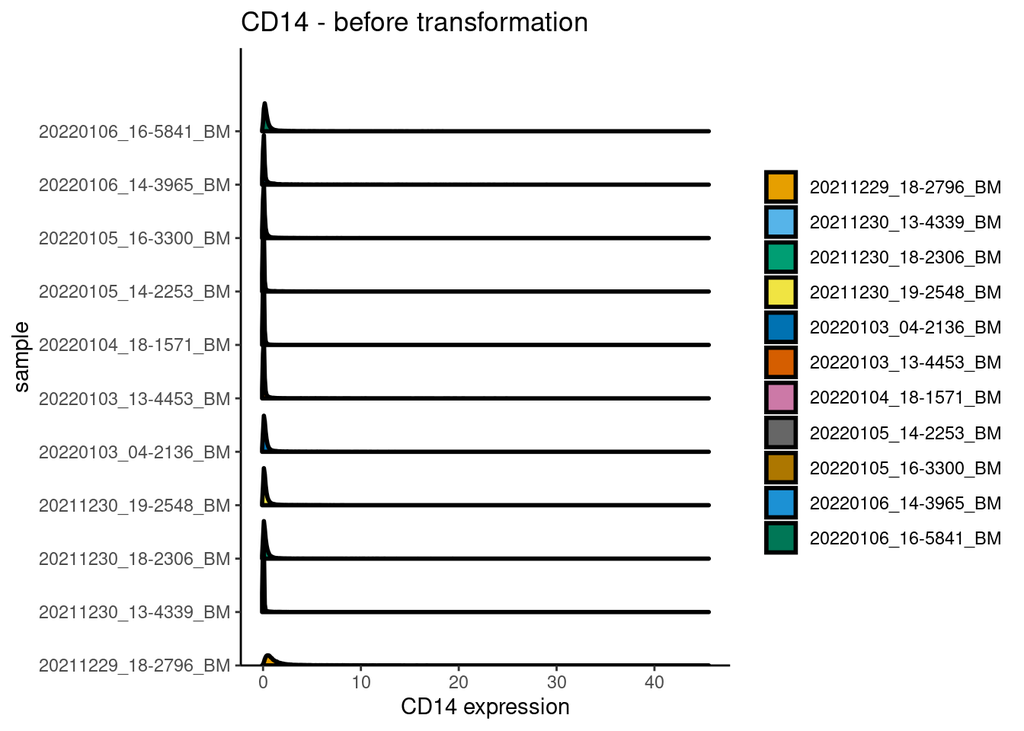

```r
dittoRidgePlot(spe[,spe$sample%in%selected_samples], var = marker, group.by = "sample", assay = "counts") +
    ggtitle(paste(marker,  "- before transformation"))
```

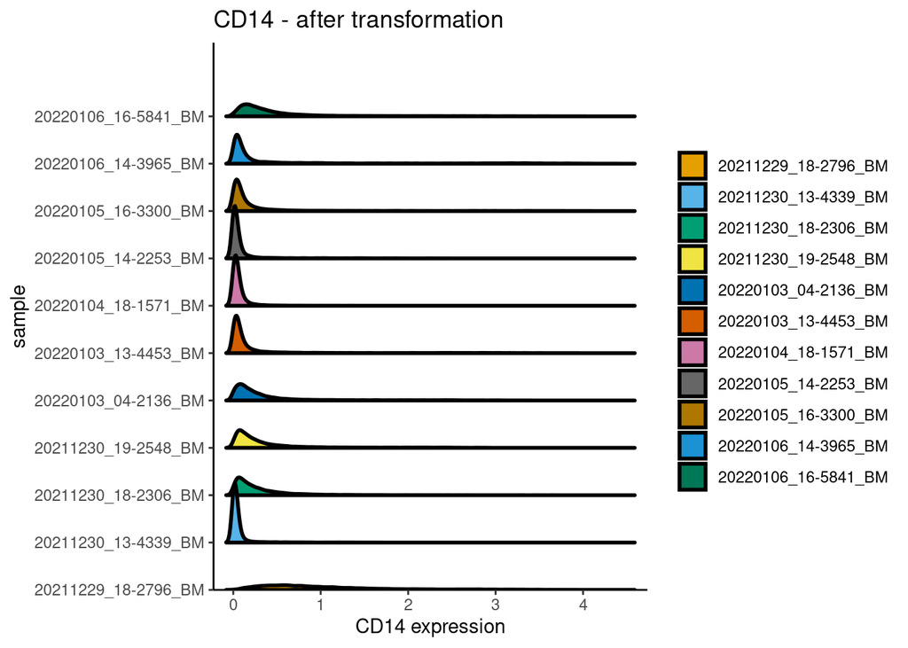

```r
dittoRidgePlot(spe[,spe$sample%in%selected_samples], var = marker, group.by = "sample", assay = "exprs") +
    ggtitle(paste(marker,  "- after transformation"))
```

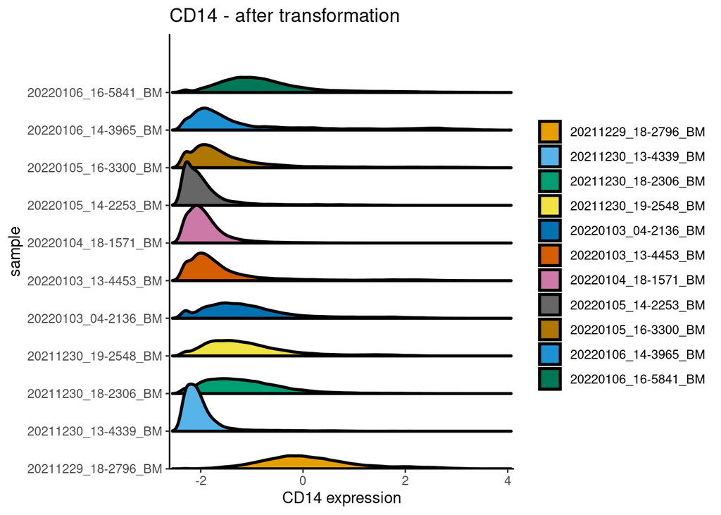

```r
dittoRidgePlot(spe[,spe$sample%in%selected_samples], var = marker, group.by = "sample", assay = "log") +
    ggtitle(paste(marker,  "- after transformation"))
```

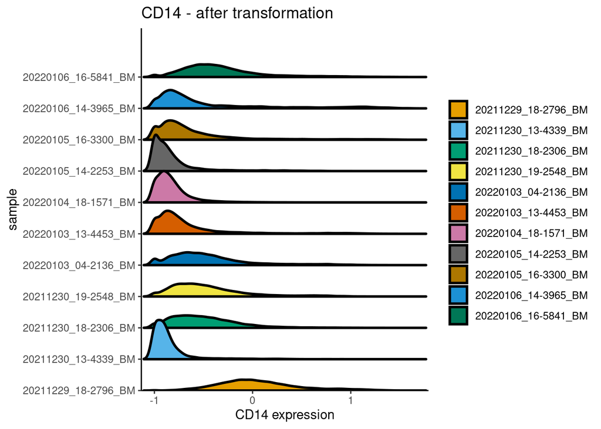

```r
dittoRidgePlot(spe[,spe$sample%in%selected_samples], var = marker, group.by = "sample", assay = "log10") +
    ggtitle(paste(marker,  "- after transformation"))
```

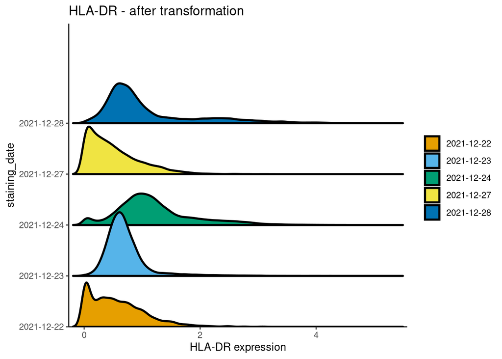

```r
marker <- 'HLA-DR'
selecting_staining_dates <- unique(spe$staining_date)[1:5]
dittoRidgePlot(spe[,spe$staining_date%in%selecting_staining_dates], var = marker, group.by = "staining_date", assay = "exprs") +
    ggtitle(paste(marker,  "- after transformation"))
```

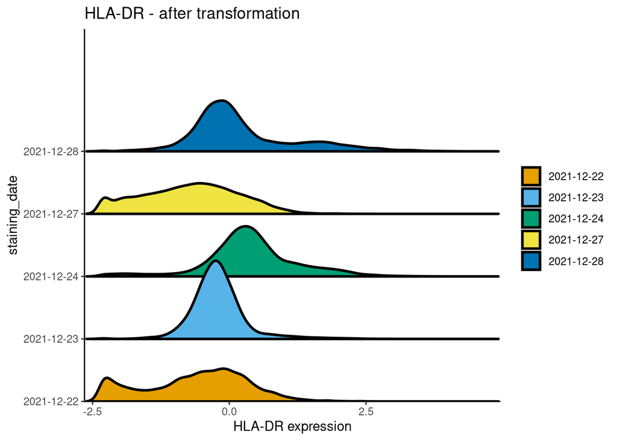

```r
dittoRidgePlot(spe[,spe$staining_date%in%selecting_staining_dates], var = marker, group.by = "staining_date", assay = "log") +
    ggtitle(paste(marker,  "- after transformation"))
```

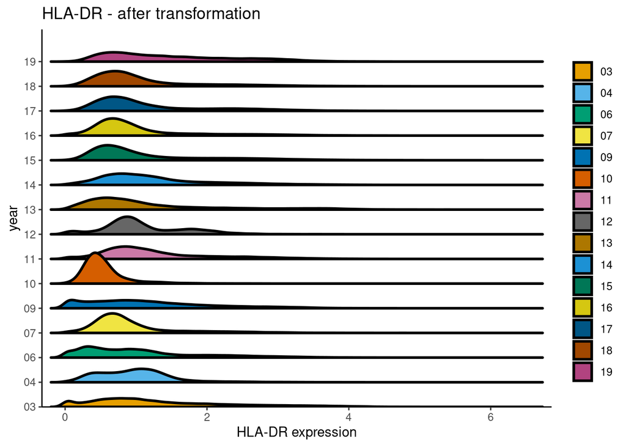

```r
marker <- 'HLA-DR'
dittoRidgePlot(spe, var = marker, group.by = "year", assay = "exprs") +
    ggtitle(paste(marker,  "- after transformation"))
```

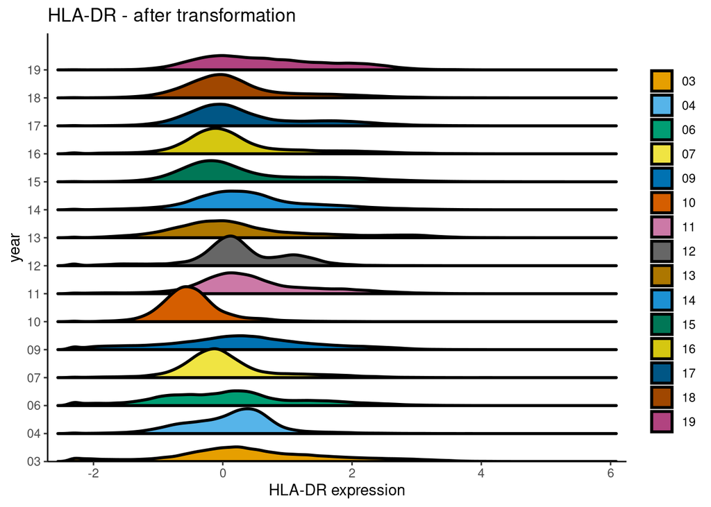

```r
dittoRidgePlot(spe, var = marker, group.by = "year", assay = "log") +
    ggtitle(paste(marker,  "- after transformation"))
```

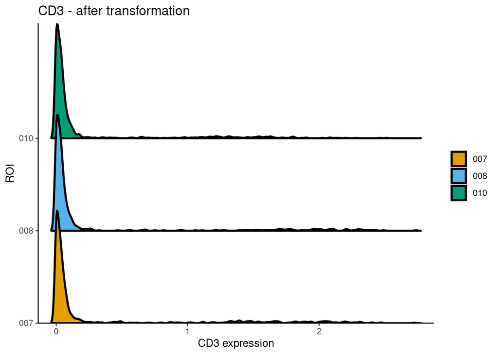

```r
marker <- 'CD3'
selected_roi <- unique(spe$sample)[3]
dittoRidgePlot(spe[,spe$sample%in%selected_roi], var = marker, group.by = "ROI", assay = "exprs") +
    ggtitle(paste(marker,  "- after transformation"))
```

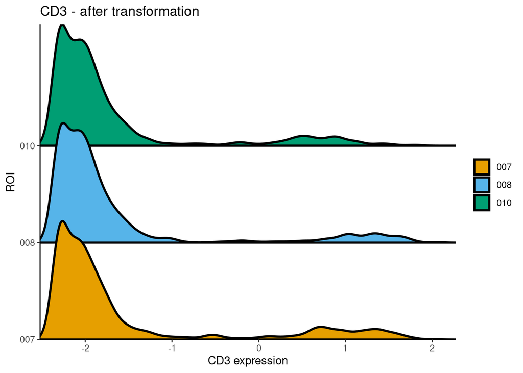

```r
dittoRidgePlot(spe[,spe$sample%in%selected_roi], var = marker, group.by = "ROI", assay = "log") +
    ggtitle(paste(marker,  "- after transformation"))
```

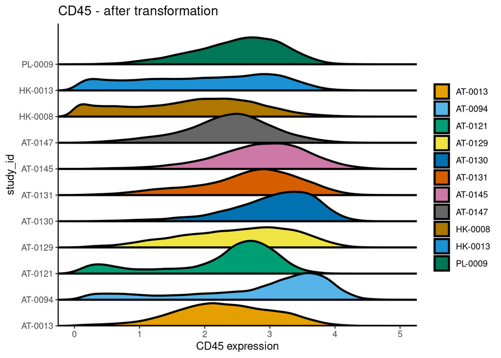

```r
selected_patients <- unique(spe$study_id)[10:20]
marker <- 'CD45'

dittoRidgePlot(spe[,spe$study_id%in%selected_patients], var = marker, group.by = "study_id", assay = "exprs") +
    ggtitle(paste(marker,  "- after transformation"))
```

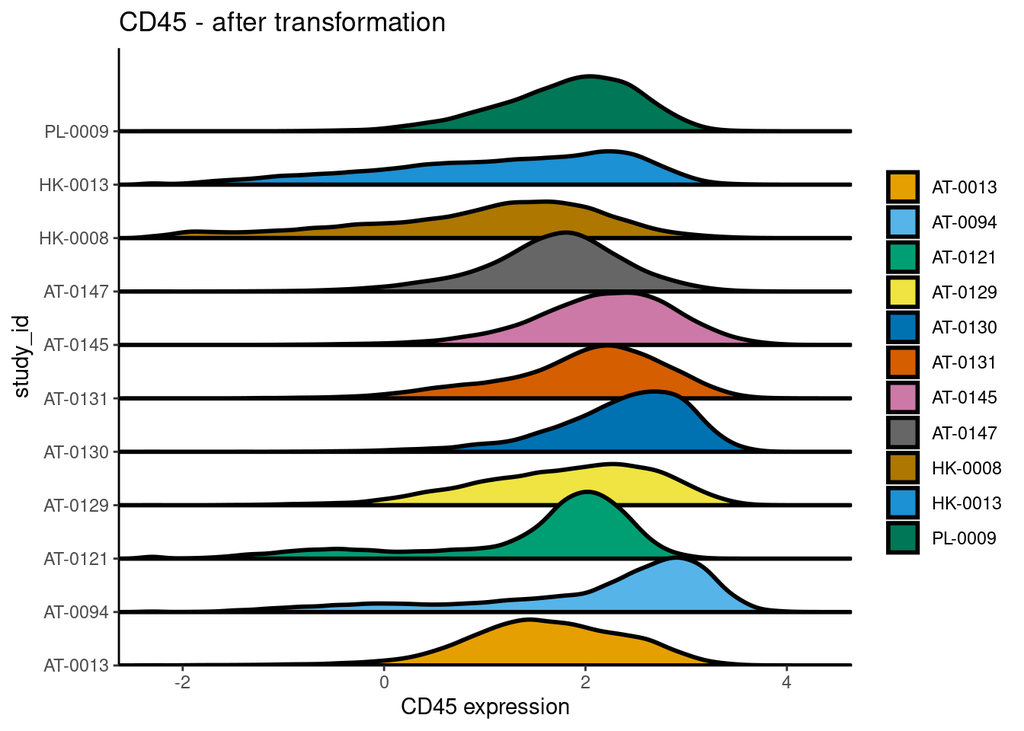

```r
dittoRidgePlot(spe[,spe$study_id%in%selected_patients], var = marker, group.by = "study_id", assay = "log") +
    ggtitle(paste(marker,  "- after transformation"))
```

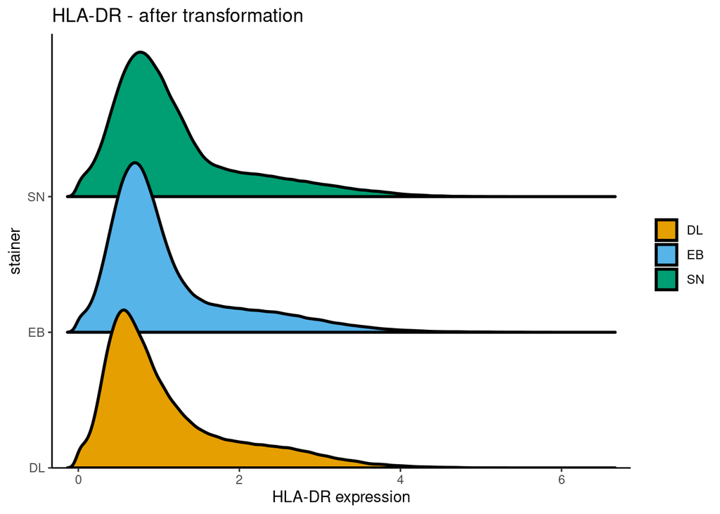

```r
marker <- 'HLA-DR'
dittoRidgePlot(spe, var = marker, group.by = "stainer", assay = "exprs") +
    ggtitle(paste(marker,  "- after transformation"))
```

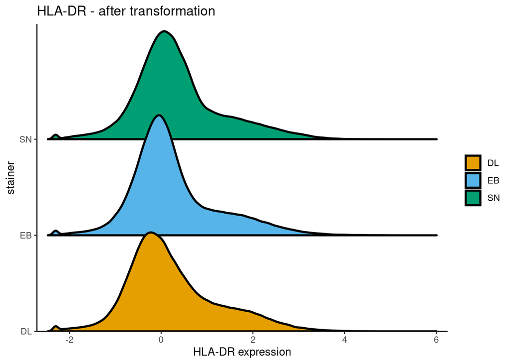

```r
dittoRidgePlot(spe, var = marker, group.by = "stainer", assay = "log") +
    ggtitle(paste(marker,  "- after transformation"))
```

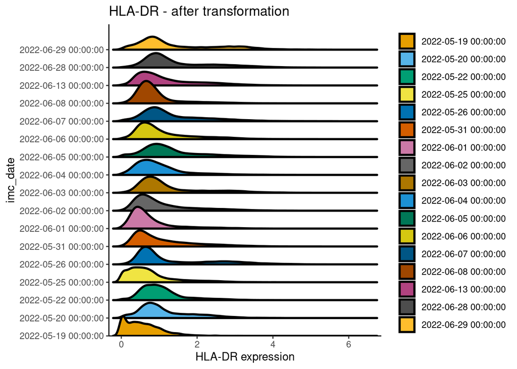

```r
marker <- 'HLA-DR'
dittoRidgePlot(spe, var = marker, group.by = "imc_date", assay = "exprs") +
    ggtitle(paste(marker,  "- after transformation"))
```

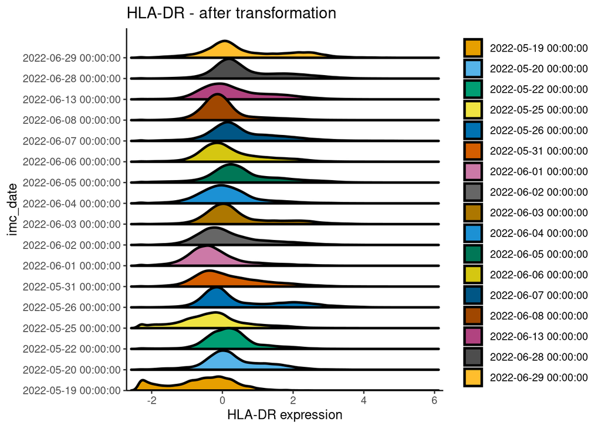

```r
dittoRidgePlot(spe, var = marker, group.by = "imc_date", assay = "log") +
    ggtitle(paste(marker,  "- after transformation"))
```

**Define interesting channels**

For downstream analysis such as visualization, dimensionality reduction and clustering, only a subset of markers should be used. As convenience, we can store an additional entry in the `rowData` slot that specifies the markers of interest. Here, we deselect the nuclear markers and keep all other biological targets.

```r
rowData(spe)$use_channel <- !grepl("Histone|H4|Iridium|DAPI|136Ba|131Xe|134Xe|GD2-IF|CD56-IF", rownames(spe))
```

**Define color schemes**

We will already at this point define color schemes for different metadata entries which will be helpful for downstream data visualizations. We will use colors from the `RColorBrewer` and `dittoSeq` package but any other coloring package will suffice.

```r
library(RColorBrewer)
color_vectors <- list()
sample <- setNames(dittoColors(reps = 1)[seq_along(unique(spe$sample))],
                unique(spe$sample))

ROI <- setNames(brewer.pal(length(unique(spe$ROI)), name = "BrBG"),
                unique(spe$ROI))

staining_date <- setNames(dittoColors(reps = 1)[seq_along(unique(spe$staining_date))],
                unique(spe$staining_batch))

color_vectors$sample <- sample
color_vectors$ROI <- ROI
color_vectors$staining_date <- staining_date
```

## Read in images

The `cytomapper` package allows multi-channel image handling and visualization within the Bioconductor framework. The most common data format for multi-channel images or segmentation masks is the TIFF file format, which is used by `steinbock` to save images.

Here, we will read in multi-channel images and segmentation masks into a [CytoImageList](https://www.bioconductor.org/packages/release/bioc/vignettes/cytomapper/inst/doc/cytomapper.html#5_The_CytoImageList_object) data container. It allows storing multiple multi-channel images and requires matched channels across all images within the object.

The `loadImages` function is used to read in processed multi-channel images and their corresponding segmentation masks as generated by `steinbock`. The multi-channel images are saved as 32-bit images while the segmentation masks are saved as 16-bit images. To correctly scale pixel values of the segmentation masks when reading them in set `as.is = TRUE`.

```r
#images <- loadImages(file.path(path,"img"))
#masks <- loadImages(file.path(path, "masks/nuclear"), as.is = TRUE)
```

In the case of multi-channel images, it is beneficial to set the `channelNames` for easy visualization. Using the `steinbock` framework, the channel order of the single-cell data matches the channel order of the multi-channel images. However, it is recommended to make sure that the channel order is known.

```r
#channelNames(images) <- rownames(spe)
```

For visualization shown in Section @ref(image-visualization) we will need to add additional metadata to the `elementMetadata` slot of the `CytoImageList` objects. This slot is easily accessible using the `mcols` function.

```r
#all.equal(names(images), names(masks))
#sample <- sub("_ROI.*", "", names(images))

#mcols(images) <- mcols(masks) <- DataFrame(image_id = names(images),
#                                           sample = sample)
```

## Save objects

Finally, the generated data objects can be saved for further downstream processing and analysis.

```r
saveRDS(spe, file.path(path, "data/spe.rds"))
#saveRDS(images, file.path(path,"data/images.rds"))
#saveRDS(masks, file.path("data/masks.rds"))
```